# Coffe Sales Analysis (Extension)

Originally by Muhammad Ahmad, Extended by Mei Qi Ng

2026-04-20

### Introduction and Setup

Here, the coffee sales data from acatlin SPRING2026TIDYVERSE Github repository to analyze monthly revenue trends and extending the analysis to view time of day purchasing behavior.

## Source

- https://github.com/acatlin/SPRING2026TIDYVERSE/blob/fa897f0cf982dc786042b49cd7f801081b9ca992/M.Ahmad_Coffe_sales.csv

```r
library(tidyverse)
```

```r
library(tidyr)
library(dplyr)
library(ggplot2)
library(naniar)
library(rmarkdown)
```

```r
url <- "https://raw.githubusercontent.com/acatlin/SPRING2026TIDYVERSE/refs/heads/main/M.Ahmad_Coffe_sales.csv"

coffeeRevenue <- read_csv(url)
coffeeRevenue
```

```
## # A tibble: 3,547 × 11
##    hour_of_day cash_type money coffee_name        Time_of_Day Weekday Month_name
##          <dbl> <chr>     <dbl> <chr>              <chr>       <chr>   <chr>
##  1          10 card       38.7 Latte              Morning     Fri     Mar
##  2          12 card       38.7 Hot Chocolate      Afternoon   Fri     Mar
##  3          12 card       38.7 Hot Chocolate      Afternoon   Fri     Mar
##  4          13 card       28.9 Americano          Afternoon   Fri     Mar
##  5          13 card       38.7 Latte              Afternoon   Fri     Mar
##  6          15 card       33.8 Americano with Mi… Afternoon   Fri     Mar
##  7          16 card       38.7 Hot Chocolate      Afternoon   Fri     Mar
##  8          18 card       33.8 Americano with Mi… Night       Fri     Mar
##  9          19 card       38.7 Cocoa              Night       Fri     Mar
## 10          19 card       33.8 Americano with Mi… Night       Fri     Mar
## # ℹ 3,537 more rows
## # ℹ 4 more variables: Weekdaysort <dbl>, Monthsort <dbl>, Date <date>,
## #   Time <time>
```

### Muhammad Ahmad Tidyverse Create

```r
glimpse(coffeeRevenue)
```

```
## Rows: 3,547
## Columns: 11
## $ hour_of_day <dbl> 10, 12, 12, 13, 13, 15, 16, 18, 19, 19, 19, 10, 10, 11, 14…
## $ cash_type   <chr> "card", "card", "card", "card", "card", "card", "card", "c…
## $ money       <dbl> 38.7, 38.7, 38.7, 28.9, 38.7, 33.8, 38.7, 33.8, 38.7, 33.8…
## $ coffee_name <chr> "Latte", "Hot Chocolate", "Hot Chocolate", "Americano", "L…
## $ Time_of_Day <chr> "Morning", "Afternoon", "Afternoon", "Afternoon", "Afterno…
## $ Weekday     <chr> "Fri", "Fri", "Fri", "Fri", "Fri", "Fri", "Fri", "Fri", "F…
## $ Month_name  <chr> "Mar", "Mar", "Mar", "Mar", "Mar", "Mar", "Mar", "Mar", "M…
## $ Weekdaysort <dbl> 5, 5, 5, 5, 5, 5, 5, 5, 5, 5, 5, 6, 6, 6, 6, 6, 6, 7, 7, 7…
## $ Monthsort   <dbl> 3, 3, 3, 3, 3, 3, 3, 3, 3, 3, 3, 3, 3, 3, 3, 3, 3, 3, 3, 3…
## $ Date        <date> 2024-03-01, 2024-03-01, 2024-03-01, 2024-03-01, 2024-03-0…
## $ Time        <time> 10:15:50, 12:19:22, 12:20:18, 13:46:33, 13:48:14, 15:39:4…
```

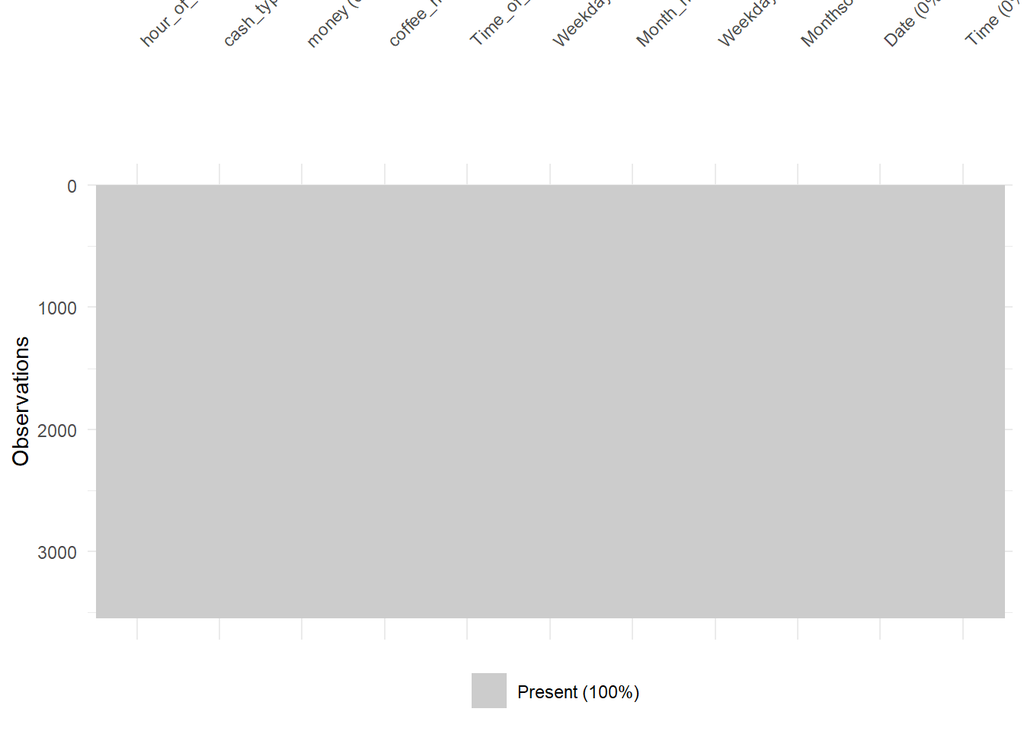

```r
vis_miss(coffeeRevenue)
```

```r
monthly <- coffeeRevenue |>
  mutate(Date = ymd(Date),
         month = floor_date(Date, "month")) |>
  group_by(month) |>
  summarise(revenue = sum(money), .groups = "drop")

monthly
```

```
## # A tibble: 13 × 2
##    month      revenue
##    <date>       <dbl>
##  1 2024-03-01   5905.
##  2 2024-04-01   5720.
##  3 2024-05-01   8164.
##  4 2024-06-01   7618.
##  5 2024-07-01   6916.
##  6 2024-08-01   7614.
##  7 2024-09-01   9989.
##  8 2024-10-01  13891.
##  9 2024-11-01   8591.
## 10 2024-12-01   8238.
## 11 2025-01-01   6399.
## 12 2025-02-01  13215.
## 13 2025-03-01   9986.
```

Monthly revenue time span

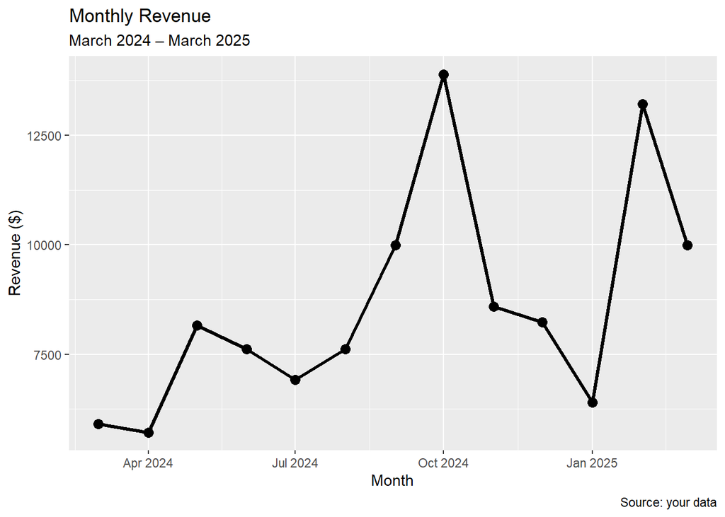

```r
ggplot(monthly, aes(x = month, y = revenue)) +
       geom_line(linewidth = 1.1) +
       geom_point(size = 3) +
  labs(
    title = "Monthly Revenue",
    subtitle = "March 2024 – March 2025",
    x = "Month",
    y = "Revenue ($)",
    caption = "Source: your data"
  )
```

### Mei Qi Ng Tidyverse Extension: Product and Time Analysis

While the initial analysis demonstrated a macro-level view of the monthly revenue, the data can be extended using ‘dply’, ‘tidyr’, and ‘ggplot2’ functions t uncover more micro-informations involving th trends which generated the sales. New features are created to analyze time of day purchasing behaviors and use faceting from ggplot2 to observe each product’s performances.

### Setup Coffee Revenue Time table

```r
coffee_EXT<- coffeeRevenue |>
  mutate(hour_of_day = hour(hms(Time)),  #converts time character string with hms()
    time_of_day = case_when(
      hour_of_day < 12 ~ "Morning",
      hour_of_day >= 12 & hour_of_day < 17 ~ "Afternoon",
      TRUE ~ "Evening")) |>
  arrange(Time)
```

### Which coffee is the most popular depending on the time of the day?

A long data frame is not the most readable for looking at the popular drink for each time of the time, hence by using group_by to get the counts for the drinks and time of the day. After pivot_wider() function can then create a wide format summary table.

```r
popular <- coffee_EXT |>
  group_by(coffee_name, time_of_day) |>
  summarise(total_orders = n(), .groups = "drop") |>
  pivot_wider(
    names_from = time_of_day, # Make table wider by creating columns from time_of_day column with valyes of total_orders column
    values_from = total_orders) |>
  # Create a total column to see overall popularity
  mutate(Total = Morning + Afternoon + Evening) |>
  arrange(desc(Total))       #arrange based on time

# Top 5 most popular displayed
head(popular, 5)
```

```
## # A tibble: 5 × 5
##   coffee_name         Afternoon Evening Morning Total
##   <chr>                   <int>   <int>   <int> <int>
## 1 Americano with Milk       239     239     331   809
## 2 Latte                     270     272     215   757
## 3 Americano                 233     112     219   564
## 4 Cappuccino                164     200     122   486
## 5 Cortado                    88      56     143   287
```

### Which coffee beverages are the top earners and how do they perform across the months?

```r
# Overall top 4

top_bev <- coffee_EXT|>
  group_by(coffee_name) |>
  summarise(total_earning = sum(money)) |>
  slice_max(order_by = total_earning, n = 4)

top_bev
```

```
## # A tibble: 4 × 2
##   coffee_name         total_earning
##   <chr>                       <dbl>
## 1 Latte                      26875.
## 2 Americano with Milk        24751.
## 3 Cappuccino                 17439.
## 4 Americano                  14650.
```

```r
# Calculate monthly revenue for these top products
top_monthly_earner <- coffee_EXT |>
  filter(coffee_name %in% top_bev$coffee_name) |>  #filter out the top 4
  mutate(month = floor_date(ymd(Date), "month")) |>    #create month column with values using lubridate function
  group_by(coffee_name, month) |>
  summarise(revenue = sum(money), .groups = "drop") |>
  print()
```

```
## # A tibble: 52 × 3
##    coffee_name month      revenue
##    <chr>       <date>       <dbl>
##  1 Americano   2024-03-01    925.
##  2 Americano   2024-04-01    942.
##  3 Americano   2024-05-01   1117.
##  4 Americano   2024-06-01    391.
##  5 Americano   2024-07-01    858.
##  6 Americano   2024-08-01    852.
##  7 Americano   2024-09-01    740.
##  8 Americano   2024-10-01   1142.
##  9 Americano   2024-11-01    649
## 10 Americano   2024-12-01    701.
## # ℹ 42 more rows
```

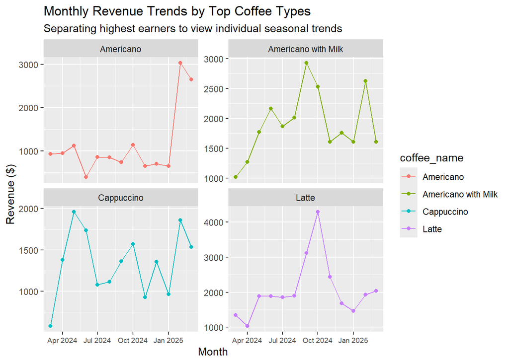

```r
# Plot using facet_wrap
ggplot(top_monthly_earner, aes(x = month, y = revenue, color = coffee_name)) +
  geom_line() +
  geom_point() +
  facet_wrap(~ coffee_name, scales = "free_y") +
  labs(
    title = "Monthly Revenue Trends by Top Coffee Types",
    subtitle = "Separating highest earners to view individual seasonal trends",
    x = "Month",
    y = "Revenue ($)")+
  theme(axis.text.x = element_text(size = 7))
```

### Wrap Up

**Conclusion**

By building on the beginning macro level revenue analysis, this extension demonstrates the time frame remodeling and data reshaping capabilities of the tidyverse. Using lubridate and case_when(), I created a categorical time of day features from the raw timestamps seen in the csv file, and after with the function pivot_wider() from the tidyr package, I transformed the long data into a tidy and wide table that showcased purchasing behaviors of clients. Furthermore, with dplyr’s slice_max() combined with ggplot2’s facet_wrap() allowed, I gathered the top 4 revenue-generating beverages (Latte, Americano with Milk, Cappuccino, and Americano) to observe their seasonal trends without creating a cluttered visualization on a single graph. Ultimately, this collaborative vignette was a great way to demonstrate how to take raw transaction logs, create new dimensions, and produce visualizations showing business sales results.